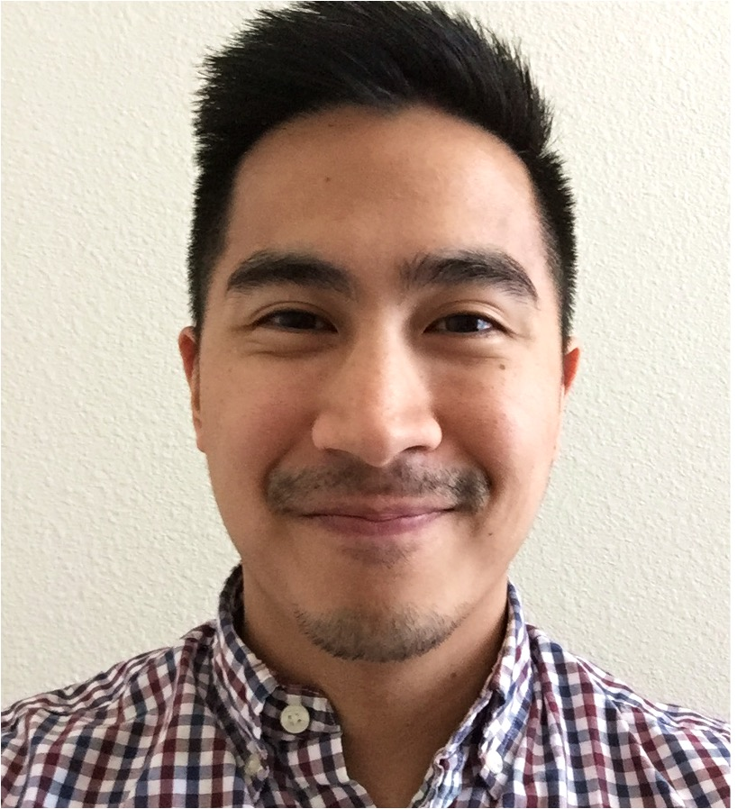

# Matt Nguyen Tran

## About

Proud Houstonian and Maryland transplant, and soon to be on the West Coast! Expertise in single-cell transcriptomics and integrating with GWAS, to learn about where genetic risk manifests. My training has been in reward neuroscience and cancer immunology, and my main interests are how to utilize various omics modalities (scRNA-seq, scATAC-seq, TWAS, etc.) to better learn about disease manifestation and/or progression.

Currently looking for industry or industry-postdoc positions in computational biology/functional genomics in the Bay Area (open to remote work). Adept at computational workflows, statistical modeling, and wet bench work (tissue culture, FACS, molecular biology, functional assays).

## Education

**John Hopkins University School of Medicine** | Baltimore, MD  
Ph.D. in Human Genetics | Aug 2017 - Mar 2022  
Thesis advisor: [Keri Martinowich, PhD](https://twitter.com/martinowk)  
**The University of Texas at Austin** | Austin, TX  
B.S. in Biology (Microbiology) | Aug 2010 - May 2014

## Experience

**Lieber Institute for Brain Development** (LIBD) | Baltimore, MD  
Research Associate | Mar 2022 - Present  
**The University of Texas MD Anderson Cancer Center** | Houston, TX  
Cell Therapy Specialist | Oct 2016 - Jun 2017  
Cell Therapy Technician | Mar 2015 - Oct 2016  
Research Assistant I | Aug 2014 - Mar 2015

## Highlighted projects

##### PhD thesis work:

Establishing a novel resource for single-nucleus RNA-sequencing in the reward circuitry of the human brain: [Tran, Maynard, et al. *Neuron* 2021](https://doi.org/10.1016/j.neuron.2021.09.001)

- Processed and sorted all samples for snRNA-seq, using 10x Genomics Chromium technology
- Developed an `R`/Bioconductor pipeline for the entire analyses, starting from raw feature-barcode matrices, reporting 107 cell classes across 5 brain regions embedded in the reward circuitry
- Quantified the genetic associations of all 107 cell classes for 12 substance use and neuropsychiatric phenotypes (from GWAS summary statistics)

##### Ongoing work at [LIBD](https://www.libd.org/team/matt-tran/):

- Generating a single-nucleus molecular transcriptomic atlas in the mouse lateral septum
- Integration of spatial and single-nucleus transcriptomics in the human locus coeruleus
- Computational onboarding and instruction/training on snRNA-seq data generation and analyses